# Bellabeat Case Study with R

Andres Diaz

2026-03-04

# Ask Phase

## Executive Summary

This study analyzed smart device usage data to uncover behavioral and physiological trends associated with daily activity levels. By examining step count, heart rate, sleep efficiency, and metabolic intensity, the analysis aimed to identify actionable insights to inform Bellabeat’s marketing strategy.

These findings reveal a strategic opportunity for Bellabeat to promote attainable activity milestones rather than exclusively emphasizing higher step targets. Positioning the 5,000-step threshold as a meaningful and realistic health benchmark can reduce psychological barriers and increase engagement. Additionally, behavioral segmentation by activity level enables more targeted communication strategies, while the underutilization of sleep tracking features highlights an opportunity to strengthen product adoption and holistic wellness messaging.

By aligning marketing initiatives with evidence-based behavioral insights, Bellabeat can enhance customer motivation, improve feature engagement, and support long-term user retention.

# Business Context

## About the Company

Urška Sršen and Sando Mur founded Bellabeat, a high-tech company that manufactures health-focused smart products. They create technology that informs and inspires women around the world. Collecting data on activity, sleep, stress, and reproductive health has allowed Bellabeat to empower women with knowledge about their own health and habits. Since it was founded in 2013, Bellabeat has grown rapidly and quickly positioned itself as a tech-driven wellness company for women.

## Stakeholders

- **Urška Sršen** (Chief Creative Officer)
- **Sando Mur** (Co-founder)
- **Bellabeat Marketing Analytics Team**

## Questions for analysis

1. What are some trends in smart device usage?
2. How could these trends apply to Bellabeat customers?
3. How could these trends help influence Bellabeat marketing strategy?

## Business Task

The objective of this analysis is to identify trends in smart device usage related to physical activity, heart rate, sleep, and metabolic intensity, and determine how these trends can inform Bellabeat’s marketing strategy.

## Selected Product for Strategic Application

For the purpose of this case study, the Bellabeat Membership platform has been selected as the primary product for strategic application.

The Membership program provides users with personalized insights, behavioral tracking, and wellness guidance. Given that this analysis identifies distinct activity-based behavioral segments and measurable physiological differences associated with moderate increases in daily movement, these insights are especially relevant for a subscription-based digital wellness service.

By applying behavioral segmentation and milestone-based motivation strategies, Bellabeat Membership can leverage data-driven marketing to enhance user engagement, retention, and long-term health adherence.

## Hypothesis

Schmidt et al. (1) demonstrated that individuals taking ≥5,000 steps per day had a substantially lower prevalence of adverse cardiometabolic health indicators compared to those taking fewer steps. Furthermore, individuals accumulating ≥12,500 steps per day showed the most favorable health profiles relative to lower activity levels.

Heart rate is widely recognized as a relevant indicator of cardiovascular health, as it reflects how efficiently the heart and circulatory system respond to rest, physical activity, and recovery. When the cardiovascular system functions efficiently, the heart does not need to beat excessively fast to supply adequate oxygen to the body.

Based on this evidence, the following hypothesis is proposed:

Individuals who accumulate ≥5,000 steps per day will present lower average resting heart rates compared to those who accumulate fewer steps.

Source: (1) Schmidt MD, Cleland VJ, Shaw K, et al. Cardiometabolic risk in younger and older adults across an index of ambulatory activity. Am J Prev Med. 2009;37:278–284. doi:10.1016/j.amepre.2009.05.020.

## Preparing workspace

The necessary packages will be installed for the processing, cleaning, analysis, and visualization of this study.

```r
library(tidyverse)
```

# Prepare Phase

## Data importation and validation

Before importing the datasets into RStudio, I reviewed the CSV files in Google Sheets to ensure they were correctly downloaded, properly formatted, and free of structural issues that could affect further processing, cleaning, analysis, or visualization.

```r
activity <- read.csv("data/dailyActivity_merged.csv")
heart_rate <- read.csv("data/heartrate_seconds_merged.csv")
sleep <- read.csv("data/sleepDay_merged.csv")
intensity <- read.csv("data/minuteMETsNarrow_merged.csv")
```

To ensure data integrity, each dataset will be validated using the functions glimpse(), n_distinct(), and head() to confirm proper structure, consistency, and successful importation.

```r
glimpse(activity)
```

```
## Rows: 940
## Columns: 15
## $ Id                       <dbl> 1503960366, 1503960366, 1503960366, 150396036…
## $ ActivityDate             <chr> "4/12/2016", "4/13/2016", "4/14/2016", "4/15/…
## $ TotalSteps               <int> 13162, 10735, 10460, 9762, 12669, 9705, 13019…
## $ TotalDistance            <dbl> 8.50, 6.97, 6.74, 6.28, 8.16, 6.48, 8.59, 9.8…
## $ TrackerDistance          <dbl> 8.50, 6.97, 6.74, 6.28, 8.16, 6.48, 8.59, 9.8…
## $ LoggedActivitiesDistance <dbl> 0, 0, 0, 0, 0, 0, 0, 0, 0, 0, 0, 0, 0, 0, 0, …
## $ VeryActiveDistance       <dbl> 1.88, 1.57, 2.44, 2.14, 2.71, 3.19, 3.25, 3.5…
## $ ModeratelyActiveDistance <dbl> 0.55, 0.69, 0.40, 1.26, 0.41, 0.78, 0.64, 1.3…
## $ LightActiveDistance      <dbl> 6.06, 4.71, 3.91, 2.83, 5.04, 2.51, 4.71, 5.0…
## $ SedentaryActiveDistance  <dbl> 0, 0, 0, 0, 0, 0, 0, 0, 0, 0, 0, 0, 0, 0, 0, …
## $ VeryActiveMinutes        <int> 25, 21, 30, 29, 36, 38, 42, 50, 28, 19, 66, 4…
## $ FairlyActiveMinutes      <int> 13, 19, 11, 34, 10, 20, 16, 31, 12, 8, 27, 21…
## $ LightlyActiveMinutes     <int> 328, 217, 181, 209, 221, 164, 233, 264, 205, …
## $ SedentaryMinutes         <int> 728, 776, 1218, 726, 773, 539, 1149, 775, 818…
## $ Calories                 <int> 1985, 1797, 1776, 1745, 1863, 1728, 1921, 203…
```

```r
head(activity)
```

```
##           Id ActivityDate TotalSteps TotalDistance TrackerDistance
## 1 1503960366    4/12/2016      13162          8.50            8.50
## 2 1503960366    4/13/2016      10735          6.97            6.97
## 3 1503960366    4/14/2016      10460          6.74            6.74
## 4 1503960366    4/15/2016       9762          6.28            6.28
## 5 1503960366    4/16/2016      12669          8.16            8.16
## 6 1503960366    4/17/2016       9705          6.48            6.48
##   LoggedActivitiesDistance VeryActiveDistance ModeratelyActiveDistance
## 1                        0               1.88                     0.55
## 2                        0               1.57                     0.69
## 3                        0               2.44                     0.40
## 4                        0               2.14                     1.26
## 5                        0               2.71                     0.41
## 6                        0               3.19                     0.78
##   LightActiveDistance SedentaryActiveDistance VeryActiveMinutes
## 1                6.06                       0                25
## 2                4.71                       0                21
## 3                3.91                       0                30
## 4                2.83                       0                29
## 5                5.04                       0                36
## 6                2.51                       0                38
##   FairlyActiveMinutes LightlyActiveMinutes SedentaryMinutes Calories
## 1                  13                  328              728     1985
## 2                  19                  217              776     1797
## 3                  11                  181             1218     1776
## 4                  34                  209              726     1745
## 5                  10                  221              773     1863
## 6                  20                  164              539     1728
```

```r
n_distinct(activity$Id)
```

```
## [1] 33
```

```r
glimpse(heart_rate)
```

```
## Rows: 2,483,658
## Columns: 3
## $ Id    <dbl> 2022484408, 2022484408, 2022484408, 2022484408, 2022484408, 2022…
## $ Time  <chr> "4/12/2016 7:21:00 AM", "4/12/2016 7:21:05 AM", "4/12/2016 7:21:…
## $ Value <int> 97, 102, 105, 103, 101, 95, 91, 93, 94, 93, 92, 89, 83, 61, 60, …
```

```r
head(heart_rate)
```

```
##           Id                 Time Value
## 1 2022484408 4/12/2016 7:21:00 AM    97
## 2 2022484408 4/12/2016 7:21:05 AM   102
## 3 2022484408 4/12/2016 7:21:10 AM   105
## 4 2022484408 4/12/2016 7:21:20 AM   103
## 5 2022484408 4/12/2016 7:21:25 AM   101
## 6 2022484408 4/12/2016 7:22:05 AM    95
```

```r
n_distinct(heart_rate$Id)
```

```
## [1] 14
```

```r
glimpse(intensity)
```

```
## Rows: 1,325,580
## Columns: 3
## $ Id             <dbl> 1503960366, 1503960366, 1503960366, 1503960366, 1503960…
## $ ActivityMinute <chr> "4/12/2016 12:00:00 AM", "4/12/2016 12:01:00 AM", "4/12…
## $ METs           <int> 10, 10, 10, 10, 10, 12, 12, 12, 12, 12, 12, 12, 10, 10,…
```

```r
head(intensity)
```

```
##           Id        ActivityMinute METs
## 1 1503960366 4/12/2016 12:00:00 AM   10
## 2 1503960366 4/12/2016 12:01:00 AM   10
## 3 1503960366 4/12/2016 12:02:00 AM   10
## 4 1503960366 4/12/2016 12:03:00 AM   10
## 5 1503960366 4/12/2016 12:04:00 AM   10
## 6 1503960366 4/12/2016 12:05:00 AM   12
```

```r
n_distinct(intensity)
```

```
## [1] 1325580
```

```r
glimpse(sleep)
```

```
## Rows: 413
## Columns: 5
## $ Id                 <dbl> 1503960366, 1503960366, 1503960366, 1503960366, 150…
## $ SleepDay           <chr> "4/12/2016 12:00:00 AM", "4/13/2016 12:00:00 AM", "…
## $ TotalSleepRecords  <int> 1, 2, 1, 2, 1, 1, 1, 1, 1, 1, 1, 1, 1, 1, 1, 1, 1, …
## $ TotalMinutesAsleep <int> 327, 384, 412, 340, 700, 304, 360, 325, 361, 430, 2…
## $ TotalTimeInBed     <int> 346, 407, 442, 367, 712, 320, 377, 364, 384, 449, 3…
```

```r
head(sleep)
```

```
##           Id              SleepDay TotalSleepRecords TotalMinutesAsleep
## 1 1503960366 4/12/2016 12:00:00 AM                 1                327
## 2 1503960366 4/13/2016 12:00:00 AM                 2                384
## 3 1503960366 4/15/2016 12:00:00 AM                 1                412
## 4 1503960366 4/16/2016 12:00:00 AM                 2                340
## 5 1503960366 4/17/2016 12:00:00 AM                 1                700
## 6 1503960366 4/19/2016 12:00:00 AM                 1                304
##   TotalTimeInBed
## 1            346
## 2            407
## 3            442
## 4            367
## 5            712
## 6            320
```

```r
n_distinct(sleep)
```

```
## [1] 410
```

## Data credibility and Limitations

### Limitations

This analysis presents several methodological and data-related limitations that must be considered when interpreting the results:

- **Resting heart rate approximation:** The minimum daily heart rate was used as a proxy for resting heart rate. While conservative, this does not guarantee that the measurement occurred under true resting physiological conditions.
- **Short observation window:** The dataset covers approximately 30 days. Long-term behavioral patterns and seasonal effects cannot be evaluated.
- **Missing sleep records:** Sleep data is incomplete for many users. This may reflect device non-use rather than absence of sleep behavior, potentially biasing sleep-related conclusions.
- **Sample representativeness:** The dataset does not include demographic variables such as age, region, or socioeconomic background. Therefore, findings cannot be generalized to the broader population of women, Bellabeat’s target market.
- **Observational nature:** The analysis identifies associations but does not establish causality between step count and improved health indicators.

### ROCCC Evaluation

| **Reliable** | Limited reliability due to small sample size |
| --- | --- |
| **Original** | Third-party source (via Kaggle) |
| **Comprehensive** | Covers activity and sleep but lacks demographic data |
| **Current** | Data collected in 2016 |
| **Cited** | Publicly available dataset on Kaggle |

# Process Phase

## Standardizing Date Formats

First we convert the date columns to Date format.

```r
activity$ActivityDate <- as.Date(activity$ActivityDate, format="%m/%d/%Y")

heart_rate$Time <- as.POSIXct(heart_rate$Time, format="%m/%d/%Y %H:%M:%S")
heart_rate$Date <- as.Date(heart_rate$Time)

sleep$SleepDay <- as.POSIXct(sleep$SleepDay, format="%m/%d/%Y %H:%M:%S")
sleep$Date <- as.Date(sleep$SleepDay)

intensity$ActivityMinute <- as.POSIXct(intensity$ActivityMinute, format="%m/%d/%Y %H:%M:%S")
intensity$Date <- as.Date(intensity$ActivityMinute)
```

## Daily Heart Rate Aggregation

```r
heart_daily <- heart_rate %>%
  group_by(Id, Date) %>%
  summarise(
    avg_hr = mean(Value, na.rm = TRUE),
    min_hr = min(Value, na.rm = TRUE)
  )
```

[output not shown]

The minimum daily heart rate is used as a conservative approximation of resting heart rate. Although this does not represent a clinically controlled resting measurement, it provides a reasonable behavioral proxy within the constraints of the dataset.

## Daily METs Aggregation

```r
mets_daily <- intensity %>%
  group_by(Id, Date) %>%
  summarise(
    avg_mets = mean(METs, na.rm = TRUE),
    total_mets = sum(METs, na.rm = TRUE)
  )
```

[output not shown]

## Daily Sleep Preparation

```r
sleep_daily <- sleep %>%
  group_by(Id, Date) %>%
  summarise(
    total_minutes_asleep = mean(TotalMinutesAsleep, na.rm = TRUE),
    total_time_in_bed = mean(TotalTimeInBed, na.rm = TRUE),
    sleep_efficiency = total_minutes_asleep / total_time_in_bed
  )
```

[output not shown]

##Joining Tables

The necessary tables from the database will be joined in order to obtain the corresponding information for each user represented in the activity table, which will be used as the primary dataset. To accomplish this, functions such as left_join() from the dplyr package will be used to merge the datasets based on a common key (user_id). This approach ensures that all users contained in the primary table are preserved while integrating relevant variables from the additional tables.

```r
final_dataset <- activity %>%
  left_join(heart_daily, by = c("Id" = "Id", "ActivityDate" = "Date")) %>%
  left_join(mets_daily, by = c("Id" = "Id", "ActivityDate" = "Date")) %>%
  left_join(sleep_daily, by = c("Id" = "Id", "ActivityDate" = "Date"))
```

This gives us a complete daily user profile.

## Strategic variables to answer the questions of the case.

### Step Classification

```r
final_dataset <- final_dataset %>%
  mutate(step_group = case_when(
    TotalSteps < 5000 ~ "Low Active",
    TotalSteps >= 5000 & TotalSteps < 10000 ~ "Moderately Active",
    TotalSteps >= 10000 ~ "Highly Active"
  ))
```

# Analyze Phase

## Trend 1: Distribution of activity level

```r
final_dataset %>%
  count(step_group)
```

```
##          step_group   n
## 1     Highly Active 303
## 2        Low Active 303
## 3 Moderately Active 334
```

This shows how users are distributed according to activity level.

## Trend 2: Steps vs Resting Heart Rate

```r
final_dataset %>%
  group_by(step_group) %>%
  summarise(avg_resting_hr = mean(min_hr, na.rm = TRUE))
```

```
## # A tibble: 3 × 2
##   step_group        avg_resting_hr
##   <chr>                      <dbl>
## 1 Highly Active               51.7
## 2 Low Active                  55.8
## 3 Moderately Active           52.1
```

Here we evaluate if the group ≥5,000 steps shows lower heart rate.

## Trend 3: Sleep Patterns by Activity Level

```r
final_dataset %>%
  group_by(step_group) %>%
  summarise(avg_sleep = mean(total_minutes_asleep, na.rm = TRUE))
```

```
## # A tibble: 3 × 2
##   step_group        avg_sleep
##   <chr>                 <dbl>
## 1 Highly Active          396.
## 2 Low Active             454.
## 3 Moderately Active      422.
```

## Trend 4: MET Intensity by Activity Level

```r
final_dataset %>%
  group_by(step_group) %>%
  summarise(avg_mets = mean(avg_mets, na.rm = TRUE))
```

```
## # A tibble: 3 × 2
##   step_group        avg_mets
##   <chr>                <dbl>
## 1 Highly Active         17.4
## 2 Low Active            11.7
## 3 Moderately Active     14.8
```

# Share Phase

## Key Insights Through Data Visualization

### Trend 1- Distribution of activity levels

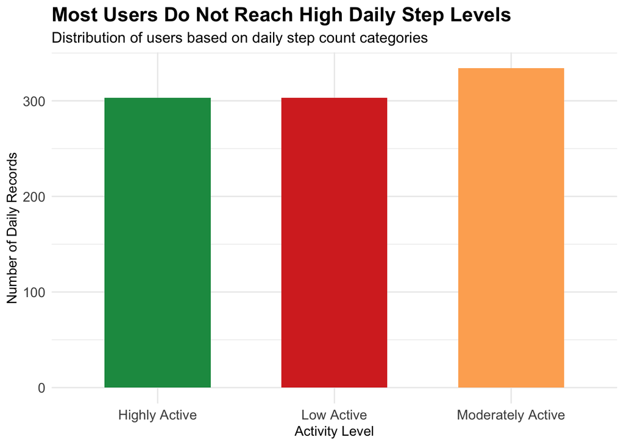

```r
ggplot(final_dataset, aes(x = step_group, fill = step_group)) +
  geom_bar(width = 0.6) +
  scale_fill_manual(values = c(
    "Low Active" = "#D73027",
    "Moderately Active" = "#FDAE61",
    "Highly Active" = "#1A9850"
  )) +
  labs(
    title = "Most Users Do Not Reach High Daily Step Levels",
    subtitle = "Distribution of users based on daily step count categories",
    x = "Activity Level",
    y = "Number of Daily Records"
  ) +
  theme_minimal() +
  theme(
    legend.position = "none",
    plot.title = element_text(size = 16, face = "bold"),
    plot.subtitle = element_text(size = 12),
    axis.text = element_text(size = 11)
  )
```

### Trend 2- Steps vs Resting Heart Rate

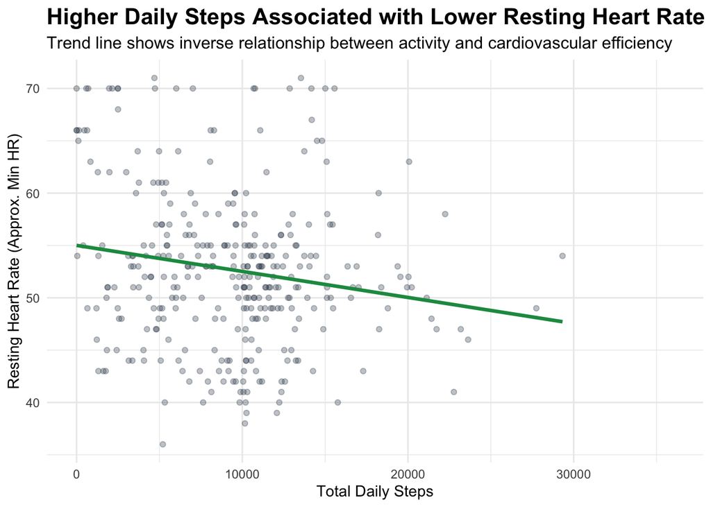

```r
ggplot(final_dataset, aes(x = TotalSteps, y = min_hr)) +
  geom_point(alpha = 0.3, color = "#2C3E50") +
  geom_smooth(method = "lm", color = "#1A9850", se = FALSE, linewidth = 1.2) +
  labs(
    title = "Higher Daily Steps Associated with Lower Resting Heart Rate",
    subtitle = "Trend line shows inverse relationship between activity and cardiovascular efficiency",
    x = "Total Daily Steps",
    y = "Resting Heart Rate (Approx. Min HR)"
  ) +
  theme_minimal() +
  theme(
    plot.title = element_text(size = 16, face = "bold"),
    plot.subtitle = element_text(size = 12)
  )
```

```r
cor(final_dataset$TotalSteps, final_dataset$min_hr, use = "complete.obs")
```

```
## [1] -0.1699318
```

#### Statistical Validation

To support the visual trend observed in the scatter plot, a correlation test was conducted between total daily steps and minimum heart rate. The results indicate a negative correlation, suggesting that higher daily step counts are modestly associated with lower minimum heart rates. While this analysis is exploratory and does not establish causation, it provides quantitative support for the observed inverse relationship.

### Trend 3- Sleep Patterns by Activity Level

[figure not shown]

```r
ggplot(final_dataset, aes(x = step_group, y = sleep_efficiency, fill = step_group)) +
  stat_summary(fun = mean, geom = "bar", width = 0.6) +
  stat_summary(fun = mean, geom = "text",
               aes(label = round(after_stat(y), 2)),
               vjust = -0.5) +
  scale_fill_manual(values = c(
    "Low Active" = "#D73027",
    "Moderately Active" = "#FDAE61",
    "Highly Active" = "#1A9850"
  )) +
  labs(
    title = "Average Sleep Efficiency by Activity Level",
    subtitle = "More active users show slightly higher average sleep efficiency",
    x = "Activity Level",
    y = "Average Sleep Efficiency"
  ) +
  theme_minimal() +
  theme(
    legend.position = "none",
    plot.title = element_text(size = 16, face = "bold")
  )
```

### Trend 4- Metabolic intensity by activity level

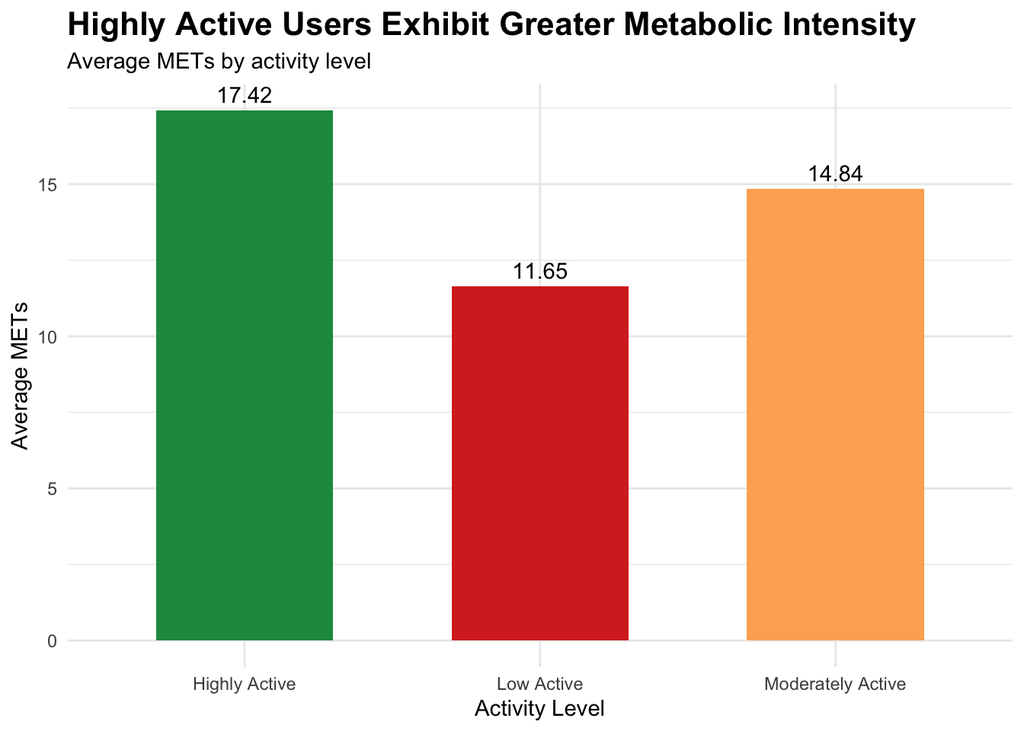

```r
ggplot(final_dataset, aes(x = step_group, y = avg_mets, fill = step_group)) +
  stat_summary(fun = mean, geom = "bar", width = 0.6) +
  stat_summary(fun = mean, geom = "text",
               aes(label = round(after_stat(y), 2)),
               vjust = -0.5) +
  scale_fill_manual(values = c(
    "Low Active" = "#D73027",
    "Moderately Active" = "#FDAE61",
    "Highly Active" = "#1A9850"
  )) +
  labs(
    title = "Highly Active Users Exhibit Greater Metabolic Intensity",
    subtitle = "Average METs by activity level",
    x = "Activity Level",
    y = "Average METs"
  ) +
  theme_minimal() +
  theme(
    legend.position = "none",
    plot.title = element_text(size = 16, face = "bold")
  )
```

# Act Phase

## Key Findings

Based on the analysis of key health-related variables (including daily physical activity, heart rate, sleep efficiency, and metabolic intensity) several meaningful trends were identified:

From a behavioral standpoint, smart device usage reveals that:

- Not all users consistently track sleep.
- Activity tracking is more consistently recorded than sleep or heart rate.
- There is a clear segmentation opportunity based on activity level.

The overall conclusion is that smart device users show measurable health-related differences based on daily step count, and moderate increases in activity (≥5,000 steps) already correspond to improved health indicators.

## Strategic Recommendations for Bellabeat

#### Promote Achievable Step Goals

Instead of emphasizing only 10,000 steps, Bellabeat should:

- Highlight the 5,000-step threshold as a meaningful health milestone.
- Position moderate activity as realistic and sustainable.
- Use messaging such as: small increases lead to measurable improvements.

This lowers psychological barriers and increases engagement.

#### Market Holistic Wellness, Not Just Activity

The data suggests that activity connects with:

- Cardiovascular efficiency
- Sleep quality
- Metabolic intensity

Bellabeat should reinforce the idea that its devices support complete wellness, not only step counting.

Marketing campaigns could integrate: *Movement*, *Rest*, and *Recovery* as a unified health narrative.

#### Segment Users by Activity Level

The analysis reveals three clear behavioral segments:

- Low Active Users -> Need motivation and entry-level goals
- Moderately Active Users -> Respond to performance improvement messaging
- Highly Active Users -> Value performance metrics and optimization

This segmentation can inform:

- Targeted email campaigns
- Personalized in-app notifications
- Customized product messaging

#### Improve Sleep Feature Engagement

The presence of missing sleep data suggests:

- Some users do not regularly use sleep tracking.
- There may be friction in night-time device usage.

Bellabeat could:

- Educate users on sleep benefits.
- Improve onboarding regarding sleep features.
- Emphasize sleep insights in marketing materials.

## Business application

Bellabeat can apply these findings by:

- Adjusting marketing messaging to emphasize attainable health improvements.
- Designing feature nudges based on user activity segments.
- Highlighting sleep and recovery as differentiators.
- Building behavioral campaigns centered around incremental improvement.

This aligns product capabilities with real user behavior patterns.

## Next Steps

- Conduct deeper statistical testing on step thresholds (5k vs 10k vs 12.5k).
- Analyze weekday vs weekend behavior differences.
- Measure retention rates by activity segment.
- Test marketing A/B campaigns emphasizing 5,000-step milestones.
- Develop predictive modeling to identify users at risk of disengagement.

## Additional Data to Strengthen Findings

To expand this analysis, the following data would be valuable:

- User demographics (age, region).
- Device usage frequency.
- App engagement metrics.
- Stress level tracking.
- Reproductive health tracking data (core Bellabeat differentiator).
- Longitudinal data beyond 30 days.

This would allow deeper behavioral modeling and more precise segmentation.